# Multilevel Linear Models

## Random Effects Models

If we want to estimate a varying intercept model by county, there are some difficulties we run into. There are 386 counties in the data, so this model would be very difficult to read and work with. As an alternative, we might want to estimate a random effects model. Doing so would let us to describe the distribution that the varying intercepts are drawn from, allowing us to better understand what a random intercept of -.72 means relative to the mean of the distributions the intercepts are drawn from, and leveraging similarities across the 386 groups. We can use the `lmer()` function in the package `lme4`, to accomplish this. This function produces a model object of class `lmerMod`. Estimate a random effects model with radon levels explained by floor and varying intercept by state (it’s much easier to understand how these models work with 9 groups instead of 386).

```r
library(lme4)
no_pooling_lme <- lmer(radon ~ floor + (1 | state2), data = sr)
```

This model assumes that there is a different baseline probability of getting a given value for `radon` based on differences in `state2`. When you call the model object, or use `summary()` on it, you’ll get the usual estimates and standard errors for your fixed effects (your regular coefficients), but only the variance and standard deviation for your random effects (the varying intercepts). Since we assume that these intercepts are all drawn from the same distribution, we can describe the set of intercepts using standard deviation or variance. If we want to examine what these intercepts actually are, we can use the `coef()` function. Using `coef()` on a `lmerMod` is convenient, because it will automatically combine any fixed and random effects (remember what these mean in `lme4`…), and then report the resulting coefficients by group membership.

```r
coef(no_pooling_lme)$state2
```

```
##    (Intercept) floor
## AZ       0.654 -0.68
## IN       1.061 -0.68
## MA       0.732 -0.68
## MI       0.083 -0.68
## MN       1.251 -0.68
## MO       0.776 -0.68
## ND       1.715 -0.68
## PA       1.232 -0.68
## WI       1.117 -0.68
```

If we want to extract the individual fixed and random effects, we can do so using `fixef()` and `ranef()`, respectively.

```r
head(ranef(no_pooling_lme)$state2)
```

```
##    (Intercept)
## AZ       -0.30
## IN        0.10
## MA       -0.23
## MI       -0.87
## MN        0.29
## MO       -0.18
```

```r
fixef(no_pooling_lme)
```

```
## (Intercept)       floor
##        0.96       -0.68
```

We can also access the standard errors of the fixed and random effects using `se.fixef()` and `se.ranef()` in the `arm` package. The `REextract()` function in `merTools` allows us to easily extract both the estimates and standard errors of random effects.

```r
library(arm)
se.ranef(no_pooling_lme)$state2
```

```
##    (Intercept)
## AZ       0.027
## IN       0.023
## MA       0.025
## MI       0.069
## MN       0.029
## MO       0.023
## ND       0.025
## PA       0.021
## WI       0.047
```

```r
se.fixef(no_pooling_lme)
```

```
## (Intercept)       floor
##       0.155       0.023
```

```r
library(merTools)
REextract(no_pooling_lme)
```

```
##   groupFctr groupID (Intercept) (Intercept)_se
## 1    state2      AZ       -0.30          0.027
## 2    state2      IN        0.10          0.023
## 3    state2      MA       -0.23          0.025
## 4    state2      MI       -0.87          0.069
## 5    state2      MN        0.29          0.029
## 6    state2      MO       -0.18          0.023
## 7    state2      ND        0.76          0.025
## 8    state2      PA        0.27          0.021
## 9    state2      WI        0.16          0.047
```

We can even combine the fixed and random effects to recover the reported effects returned by `coef()`. Let’s try this for Missouri, comparing the effect of both the intercept and `floor`.

```r
fixef(no_pooling_lme)[1] == coef(no_pooling_lme)$state2[6,1]
fixef(no_pooling_lme)[1] + ranef(no_pooling_lme)$state2[6,] == coef(no_pooling_lme)$state2[6, 1]
fixef(no_pooling_lme)[2] == coef(no_pooling_lme)$state2[6, 2]
```

```
## (Intercept)
##       FALSE
## (Intercept)
##        TRUE
## floor
##  TRUE
```

An important thing to note here, is that the intercept is affected by the random effect. In this case, the intercept in the random effect term `(1 | state2)` represents a baseline relative to all the states included in the data, so we need to combine the fixed and random effect of the intercept to get its total effect. In other words, the first entry in `coef()` represents a case *not* represented in the data because it is a baseline that all of the states are relative to. However, this model doesn’t have a random effect varying slope term, so the fixed effect of `floor` is its total effect.

This is a lot of words to describe what’s happening in a random effects varying intercept model, but sometimes it’s easier to understand with a picture. Use the `predict()` function on our `lmerMod` object to get fitted values and then plot `radon` and `floor` values with the regression line for each state.

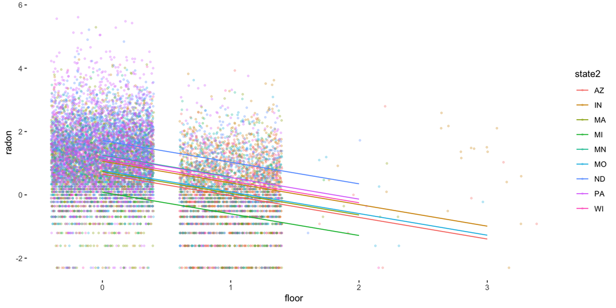

```r
sr$fit <- predict(no_pooling_lme)
ggplot(data = sr, aes(x = floor, y = radon, color = state2)) +
  geom_point(alpha = .25, position = 'jitter', size = .75) +
  geom_line(aes(y = fit)) +
  theme_bw() +
  theme(legend.position = 'right',
        plot.background = element_blank(),
        panel.grid.minor = element_blank(),
        panel.grid.major = element_blank(),
        panel.border = element_blank())
```

Now let’s add some county-level data to our data so that we can include effects as a function of county-level differences. Load the data file of county level info from http://www.stat.columbia.edu/~gelman/arm/examples/radon/cty.dat.

```r
cty <- read.delim('http://www.stat.columbia.edu/~gelman/arm/examples/radon/cty.dat', sep = ',')
sr$fips <- sr$stfips * 1000 + sr$cntyfips
cty$fips <- cty$stfips * 1000 + cty$ctfips
ml_data <- merge(sr, cty)
```

```r
mlm <- lmer(radon ~ floor + typebldg + (1 | Uppm), data = ml_data)
```

Note that in this case, the baseline case where `Uppm` = 0 makes sense because this is a measurement, and we have 165 cases in our data where `Uppm` actually does equal zero. Thus, `coef(mlm)$Uppm[1, 1]` represents the actual intercept in these cases, which is a combination of `fixef(mlm)[1]` and `ranef(mlm)$Uppm[1, ]`.

```r
coef(mlm)$Uppm[1, 1] == fixef(mlm)[1] + ranef(mlm)$Uppm[1,]
```

```
## (Intercept)
##        TRUE
```

The real advantage of `lme4` however, is its ability to specify varying *slope* random effects models. In these models, the effect of a coefficient is dependent on group membership. Write a model where `radon` is explained by `typebuilding`, but with a coefficient that varies by `state2`. We can think of this model as an interaction, since the coefficient for the effect of `typebldg` on `radon` is a function of the value of `state2`.

```r
mlm <- lmer(radon ~ (typebldg | state2), data = ml_data)
```

As with the fixed effects model above, we can access the fixed, random, and total effects separately. Compare the `typebldg` coefficient for Indiana in the random effect component to the `typebldg` coefficient for Indiana.

```r
coef(mlm)$state2
```

```
##    typebldg (Intercept)
## AZ   -0.029       0.022
## IN   -0.158       0.889
## MA   -0.094       0.765
## MI    0.043      -0.369
## MN   -0.225       1.342
## MO   -0.192       0.710
## ND   -0.202       1.829
## PA   -0.160       1.328
## WI   -0.156       0.828
```

```r
fixef(mlm)
```

```
## (Intercept)
##        0.14
```

```r
ranef(mlm)$state2
```

```
##    (Intercept) typebldg
## AZ       -0.11   -0.029
## IN        0.75   -0.158
## MA        0.63   -0.094
## MI       -0.51    0.043
## MN        1.21   -0.225
## MO        0.57   -0.192
## ND        1.69   -0.202
## PA        1.19   -0.160
## WI        0.69   -0.156
```

```r
ranef(mlm)$state2[2, 2] == coef(mlm)$state2[2, 1]
```

```
## [1] TRUE
```

Just like we can use plots to visually explore the effect of random intercepts, we can do the same with random slopes. Use the `predict()` command again to create a scatter plot of radon levels against building type, and include the linear regression line for each state.

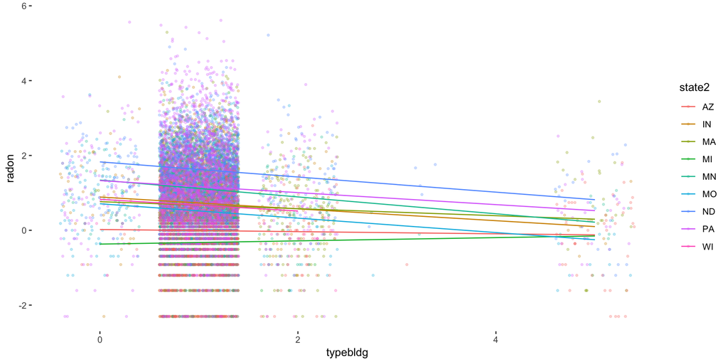

```r
ml_data$fit<- predict(mlm)
slope_plot <- ggplot(data = ml_data, aes(x = typebldg, y = radon, color = state2)) +
  geom_point(alpha = .25, position = 'jitter', size = .75) +
  geom_line(aes(y = fit)) +
  theme_bw() +
  theme(legend.position = 'right',
        plot.background = element_blank(),
        panel.grid.minor = element_blank(),
        panel.grid.major = element_blank(),
        panel.border = element_blank())
slope_plot
```

In this case, the coefficient of `typebldg` is equal to the random effect because we did not specify a fixed effect for it in the model formula. If we did, then we would have to combine the appropriate random effect with the fixed effect to obtain our total effect. Try this with a model that explain `radon` as a function of `floor` and `typebldg`, with a varying coefficient on `typebldg` by `Uppm`.

```r
mlm <- lmer(radon ~ floor + typebldg + (typebldg | Uppm), data = ml_data)
summary(mlm)
```

```
## Linear mixed model fit by REML ['lmerMod']
## Formula: radon ~ floor + typebldg + (typebldg | Uppm)
##    Data: ml_data
##
## REML criterion at convergence: 35058
##
## Scaled residuals:
##    Min     1Q Median     3Q    Max
## -4.594 -0.610 -0.001  0.605  5.176
##
## Random effects:
##  Groups   Name        Variance Std.Dev. Corr
##  Uppm     (Intercept) 0.30489  0.5522
##           typebldg    0.00225  0.0474   -0.64
##  Residual             0.88247  0.9394
## Number of obs: 12631, groups:  Uppm, 463
##
## Fixed effects:
##             Estimate Std. Error t value
## (Intercept)   1.2100     0.0356   34.02
## floor        -0.7049     0.0222  -31.73
## typebldg     -0.1142     0.0177   -6.45
##
## Correlation of Fixed Effects:
##          (Intr) floor
## floor    -0.204
## typebldg -0.562 -0.061
```

```r
ranef(mlm)$Uppm[2, 2] == coef(mlm)$Uppm[2, 3]
```

```
## [1] FALSE
```

```r
fixef(mlm)[3] + ranef(mlm)$Uppm[2, 2] == coef(mlm)$Uppm[2, 3]
```

```
## typebldg
##     TRUE
```

We can also specify a random effects model without a varying intercept term. Try writing a model that explains the radon level as a function of `typebuilding` with a varying slope by `state2`. Look at the summary of the model object and notice that there is no longer an intercept listed under the random effects. This means that observations in each group will have their own slope, but use the overall intercept. Plotting this model clearly illustrates the difference between one with an intercept in the random effect term

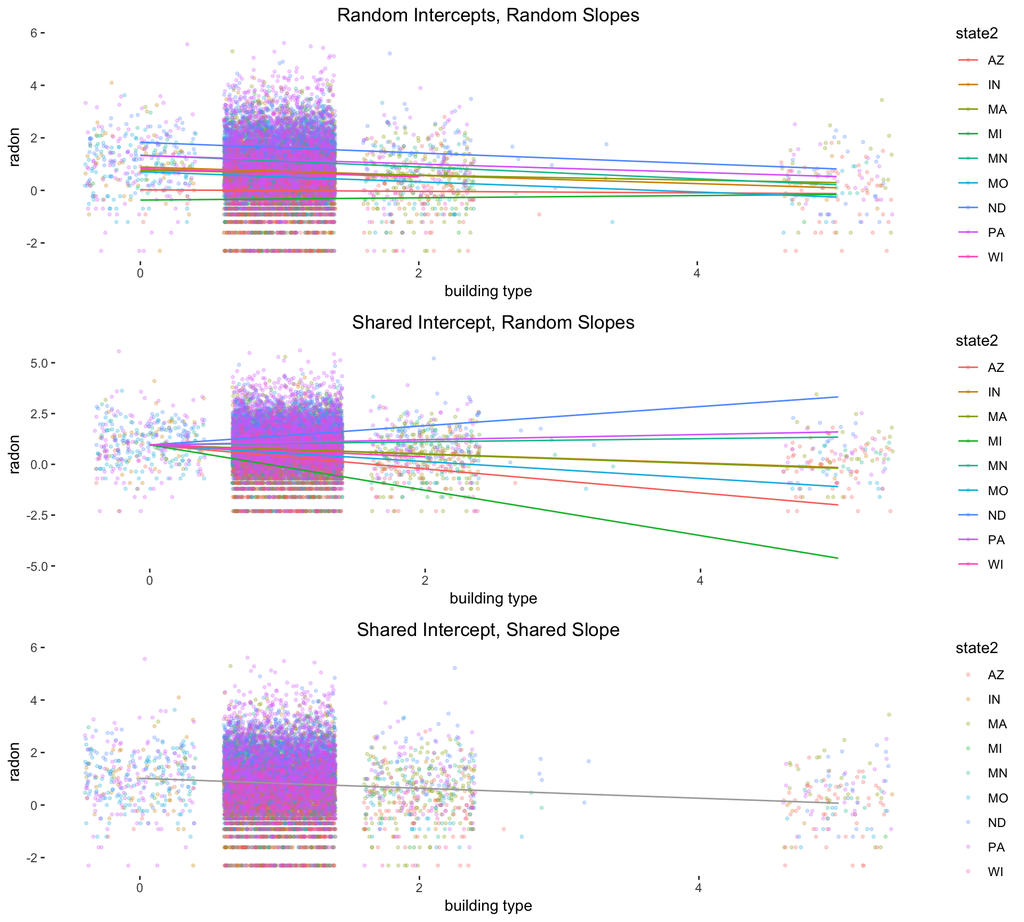

```r
mlm <- lmer(radon ~ (typebldg - 1 | state2), data = ml_data)
ml_data$fit <- predict(mlm)
slope_plot_noint <- ggplot(data = ml_data, aes(x = typebldg, y = radon, color = state2)) +
  geom_point(alpha = .25, position = 'jitter', size = .75) +
  geom_line(aes(y = fit)) +
  labs(title = 'Shared Intercept, Random Slopes', x = 'building type') +
  theme_bw() +
  theme(plot.title = element_text(hjust = 0.5),
        legend.position = 'right',
        plot.background = element_blank(),
        panel.grid.minor = element_blank(),
        panel.grid.major = element_blank(),
        panel.border = element_blank())
slope_plot <- slope_plot +
  labs(title = 'Random Intercepts, Random Slopes', x = 'building type') +
  theme(plot.title = element_text(hjust = 0.5))
ml_data$fit <- predict(lm(radon ~ typebldg, data = ml_data))
slope_plot_pool <- ggplot(data = ml_data, aes(x = typebldg, y = radon, color = state2)) +
  geom_point(alpha = .25, position = 'jitter', size = .75) +
  geom_line(aes(y = fit), color = 'darkgrey') +
  labs(title = 'Shared Intercept, Shared Slope', x = 'building type') +
  theme_bw() +
  theme(plot.title = element_text(hjust = 0.5),
        legend.position = 'right',
        plot.background = element_blank(),
        panel.grid.minor = element_blank(),
        panel.grid.major = element_blank(),
        panel.border = element_blank())

## arrange in order of increasing similarity
gridExtra::grid.arrange(slope_plot, slope_plot_noint, slope_plot_pool, nrow = 3)
```

By default, `lme4` assumes that random effects sharing the same factor are correlated. This is based on the assumption of unit heterogeneity i.e. that there are unobserved factors at the group level that lead to differences in the effect of certain variables. If we think that there are group level effects, but that these effects are independent of one another, we can model them independently by using two pipes instead of one in the random effect term in the formula. This is similar to, but not quite the same as specifying two different random effect terms. If we suppressed the intercept in all random effect terms, then they would be equivalent e.g. `(typebldg + stratum - 1 || Uppm)` = `(typebldg - 1 | Uppm) + (stratum - 1 | Uppm)`.

```r
mlm <- lmer(radon ~ floor + (typebldg + stratum | Uppm), data = ml_data)
summary(mlm)$varcor
```

```
##  Groups   Name        Std.Dev. Corr
##  Uppm     (Intercept) 0.5376
##           typebldg    0.0858   -0.25
##           stratum     0.0172   -0.09 -0.20
##  Residual             0.9400
```

```r
mlm <- lmer(radon ~ floor + (typebldg + stratum || Uppm), data = ml_data)
summary(mlm)$varcor
```

```
##  Groups   Name        Std.Dev.
##  Uppm     (Intercept) 0.5116
##  Uppm.1   typebldg    0.0709
##  Uppm.2   stratum     0.0153
##  Residual             0.9403
```

## Individual Exercise

Use the `WDI` package to download GDP per capita (NY.GDP.PCAP.KD) and gross domestic savings (NY.GNS.ICTR.ZS) data for the Nordic countries from 1960-2016. Fit varying intercept, varying slope, and varying intercept and slope random effects models that explain GDP as a function of savings, with country as the group. Produce plots illustrating the regression lines for each country in each model.

[^1]: Metaphor borrowed from [Johannes Karreth](http://www.jkarreth.net/).